# Urban landscape tendencies - PPP

**SUPUESTO 1:** Se trabaja sobre la idea que buscamos tipologías con potencial de edificación en altura

# AREA DE INTERVENCION

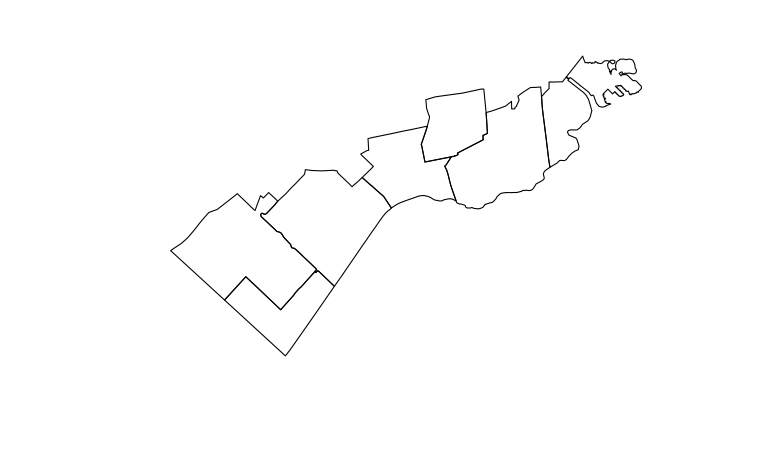

# TIPOLOGIAS RESIDENCIALES

Los PH y las casas son tipologías de baja densidad. Los lugares de mayor concentración, podrían representar un mayor incentivo para la compra de lote + edificación.

```
tmap mode set to interactive viewing
```

[interactive chart not shown]

La estrategia de modelado es lineal donde `tipo ~ lon+lat, family=bynomial` (una estimación de probabilidad). La relación entre x e y podría ser `lon+lat` ó `poly(lon,3)*poly(lat,3)`, etc. En este output es, `bs(lon,4)*bs(lat,4)` - polynomial spline.

```
Casa   PH
 280  513

     Casa        PH
0.3530895 0.6469105
```

```
Call:
glm(formula = tipo ~ bs(lon, 4) * bs(lat, 4), family = "binomial",
    data = tipo_oferta_sur)

Deviance Residuals:
    Min       1Q   Median       3Q      Max
-2.4273  -1.1709   0.6596   0.9295   2.4328

Coefficients:
                         Estimate Std. Error z value Pr(>|z|)
(Intercept)                -42.52      19.29  -2.205   0.0275 *
bs(lon, 4)1                 99.17      46.51   2.132   0.0330 *
bs(lon, 4)2                -88.18      76.66  -1.150   0.2500
bs(lon, 4)3                131.43     380.42   0.345   0.7297
bs(lon, 4)4               3207.83    3996.93   0.803   0.4222
bs(lat, 4)1                 72.15      34.20   2.110   0.0349 *
bs(lat, 4)2                 -5.40      19.09  -0.283   0.7773
bs(lat, 4)3                132.70      60.98   2.176   0.0295 *
bs(lat, 4)4             -21299.52   18216.66  -1.169   0.2423
bs(lon, 4)1:bs(lat, 4)1   -153.31      71.06  -2.157   0.0310 *
bs(lon, 4)2:bs(lat, 4)1    122.44      73.97   1.655   0.0979 .
bs(lon, 4)3:bs(lat, 4)1   -236.62     394.02  -0.601   0.5482
bs(lon, 4)4:bs(lat, 4)1  -3184.10    4064.01  -0.783   0.4333
bs(lon, 4)1:bs(lat, 4)2    -36.41      34.52  -1.055   0.2916
bs(lon, 4)2:bs(lat, 4)2     96.22      85.99   1.119   0.2632
bs(lon, 4)3:bs(lat, 4)2    -46.55     372.62  -0.125   0.9006
bs(lon, 4)4:bs(lat, 4)2  -3168.04    3982.59  -0.795   0.4263
bs(lon, 4)1:bs(lat, 4)3   -194.88      89.81  -2.170   0.0300 *
bs(lon, 4)2:bs(lat, 4)3     21.13      83.59   0.253   0.8004
bs(lon, 4)3:bs(lat, 4)3   -237.05     391.05  -0.606   0.5444
bs(lon, 4)4:bs(lat, 4)3  -3289.57    4000.06  -0.822   0.4109
bs(lon, 4)1:bs(lat, 4)4  21117.66   18208.59   1.160   0.2461
bs(lon, 4)2:bs(lat, 4)4  21442.87   18213.40   1.177   0.2391
bs(lon, 4)3:bs(lat, 4)4  21221.99   18243.06   1.163   0.2447
bs(lon, 4)4:bs(lat, 4)4  18134.23   18570.79   0.976   0.3288
---
Signif. codes:  0 ‘***’ 0.001 ‘**’ 0.01 ‘*’ 0.05 ‘.’ 0.1 ‘ ’ 1

(Dispersion parameter for binomial family taken to be 1)

    Null deviance: 1029.85  on 792  degrees of freedom
Residual deviance:  936.95  on 768  degrees of freedom
AIC: 986.95

Number of Fisher Scoring iterations: 4

   Min. 1st Qu.  Median    Mean 3rd Qu.    Max.
0.00000 0.01025 0.55619 0.50776 0.94835 1.00000
```

```
   Min. 1st Qu.  Median    Mean 3rd Qu.    Max.    NA's
  0.002   0.409   0.570   0.544   0.731   0.992    5687
```

[interactive chart not shown]

El resultado (siguiendo la formula lineal que indicamos arriba) estaría indicando una mayor probabilidad de ocurrencia del proceso marcado hacia el este de la comuna 4. Esto podría ser un insight del escenario de base.

**SUPUESTO 2**: MODIFICACION DE LA TENDENCIA ESPACIAL DE PRECIOS.

Para el armado de un escenario de base, se podría evaluar la tendencia actual de precios en el territorio e ir evaluando cómo esto cambia a medida que se agregan nuevas realizaciones de procesos marcados (que en otras palabras son nuevos desarrollos llevados a cabo).

A medida que se agregan nuevos puntos uno puede interpretar que son nuevos agentes construyendo (lo que en iteraciones posteriores iría modificando la tendencia del precio sobre el territorio)

Localizacion de la oferta de suelo Q1-2021.

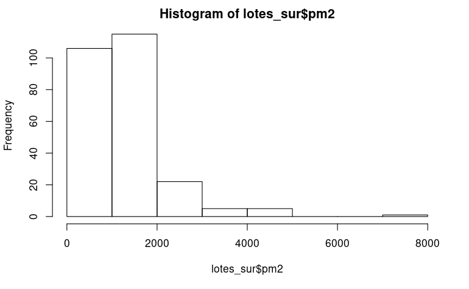

```
tmap mode set to interactive viewing
```

[interactive chart not shown]

EVALUACION DEL PRECIO POR M2 EN FUNCION DE LA DISTANCIA RECIPROCA. ESTE ESCENARIO EVALUA EL IMPACTO DE LA UBICACION Y LA SUPERFICIE EN LOS PRECIOS DE SUELO.

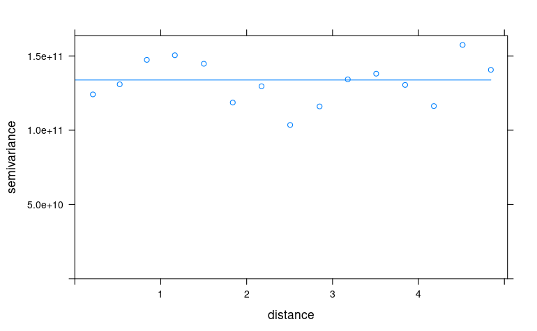

```r
plot(lotes_vgm, lotes_vgm_fit)
```

SE APLICA KRIGING Y SE EVALUA EL LAG ESPACIAL DEL ERROR PARA LA PREDICCION

```
This build of rgl does not include OpenGL functions.  Use
 rglwidget() to display results, e.g. via options(rgl.printRglwidget = TRUE).
```

```
[using universal kriging]
Object of class SpatialPointsDataFrame
Coordinates:
                min      max
coords.x1 -58.49987 -58.3580
coords.x2 -34.69490 -34.6265
Is projected: FALSE
proj4string : [+proj=longlat +datum=WGS84 +no_defs]
Number of points: 10000
Data attributes:
   var1.pred           var1.var
 Min.   :-1116.80   Min.   :1.348e+11
 1st Qu.:  -25.34   1st Qu.:1.370e+11
 Median :  678.20   Median :1.404e+11
 Mean   :  678.20   Mean   :1.423e+11
 3rd Qu.: 1381.74   3rd Qu.:1.454e+11
 Max.   : 2473.20   Max.   :1.737e+11
```

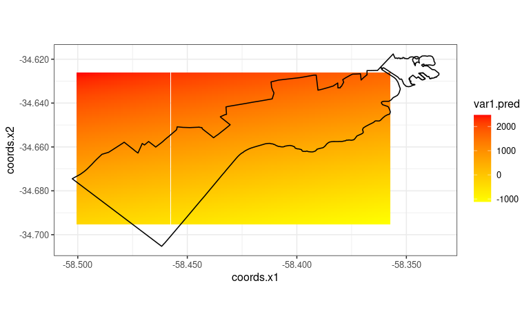

```
[generalized least squares trend estimation]
Object of class SpatialPointsDataFrame
Coordinates:
                min      max
coords.x1 -58.49987 -58.3580
coords.x2 -34.69490 -34.6265
Is projected: FALSE
proj4string : [+proj=longlat +datum=WGS84 +no_defs]
Number of points: 10000
Data attributes:
    pm2.pred           pm2.var
 Min.   :-1116.80   Min.   :1.010e+09
 1st Qu.:  -25.34   1st Qu.:3.249e+09
 Median :  678.20   Median :6.646e+09
 Mean   :  678.20   Mean   :8.533e+09
 3rd Qu.: 1381.74   3rd Qu.:1.165e+10
 Max.   : 2473.20   Max.   :3.992e+10
```

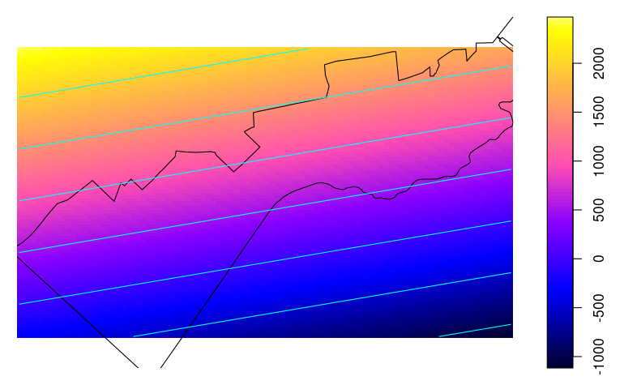